# Project 1

## Missing data in R

- R has two types of missing data
  - NA
  - NULL

### NA type missing data in R

```r
zchar <- c("Hockey", NA,"Cricket")
nchar(z)
```

```
## [1] 1 1
```

```r
z <- c(1,2,NA,8,3,NA,3)
mean(z)
```

```
## [1] NA
```

```r
#The “is.na” function tests each element of vector for missingness
is.na(z)
```

```
## [1] FALSE FALSE  TRUE FALSE FALSE  TRUE FALSE
```

```r
#The na.rm function with =TRUE argument will remove NA so that we can get values for:
mean(z, na.rm=TRUE)
```

```
## [1] 3.4
```

```r
var(z, na.rm=TRUE)
```

```
## [1] 7.3
```

```r
sd(z, na.rm=TRUE)
```

```
## [1] 2.701851
```

### NULL type missing data in R

```r
z <- c(1, NULL, 3) # NULL is the absence of anything
is.null(z)
```

```
## [1] FALSE
```

```r
d <- NULL
is.null(d)
```

```
## [1] TRUE
```

```r
is.null(7)
```

```
## [1] FALSE
```

## Pipes in R

```r
x <- 1:10
mean(x)
```

```
## [1] 5.5
```

```r
library(magrittr)
# Mean of x with pipe:
x %>% mean
```

```
## [1] 5.5
```

## Chained pipes in R

```r
z <-c(1,2,NA,8,3,NA,3)
sum(is.na(z))
```

```
## [1] 2
```

```r
#Pipes, without nesting
z %>% is.na %>% sum
```

```
## [1] 2
```

```r
#Additional argument
z %>% mean(na.rm=TRUE)
```

```
## [1] 3.4
```

## Advanced data structures in R

```r
x <- 10:1
y <- -4:5
q <-c("Hockey", "Football","Baseball", "Kabaddi", "Rugby", "Pingpong", "Basketball","Tennis","Cricket", "Volleyball")
theDF <-data.frame(x, y, q)
theDF
```

```
##     x  y          q
## 1  10 -4     Hockey
## 2   9 -3   Football
## 3   8 -2   Baseball
## 4   7 -1    Kabaddi
## 5   6  0      Rugby
## 6   5  1   Pingpong
## 7   4  2 Basketball
## 8   3  3     Tennis
## 9   2  4    Cricket
## 10  1  5 Volleyball
```

## Advanced data structures in R

```r
theDF <-data.frame(First=x, Second=y, Sport=q)
names(theDF)
```

```
## [1] "First"  "Second" "Sport"
```

```r
names(theDF)[3]
```

```
## [1] "Sport"
```

```r
rownames(theDF)
```

```
##  [1] "1"  "2"  "3"  "4"  "5"  "6"  "7"  "8"  "9"  "10"
```

```r
rownames(theDF) <- c("One", "Two", "Three", "Four", "Five", "Six", "Seven", "Eight", "Nice", "Ten")
rownames(theDF)
```

```
##  [1] "One"   "Two"   "Three" "Four"  "Five"  "Six"   "Seven" "Eight" "Nice"
## [10] "Ten"
```

```r
# Setting them back to generic index
rownames(theDF) <- NULL
rownames(theDF)
```

```
##  [1] "1"  "2"  "3"  "4"  "5"  "6"  "7"  "8"  "9"  "10"
```

```r
head(theDF)
```

```
##   First Second    Sport
## 1    10     -4   Hockey
## 2     9     -3 Football
## 3     8     -2 Baseball
## 4     7     -1  Kabaddi
## 5     6      0    Rugby
## 6     5      1 Pingpong
```

```r
head(theDF, n=7)
```

```
##   First Second      Sport
## 1    10     -4     Hockey
## 2     9     -3   Football
## 3     8     -2   Baseball
## 4     7     -1    Kabaddi
## 5     6      0      Rugby
## 6     5      1   Pingpong
## 7     4      2 Basketball
```

```r
tail(theDF)
```

```
##    First Second      Sport
## 5      6      0      Rugby
## 6      5      1   Pingpong
## 7      4      2 Basketball
## 8      3      3     Tennis
## 9      2      4    Cricket
## 10     1      5 Volleyball
```

```r
class(theDF)
```

```
## [1] "data.frame"
```

```r
str(theDF)
```

```
## 'data.frame':    10 obs. of  3 variables:
##  $ First : int  10 9 8 7 6 5 4 3 2 1
##  $ Second: int  -4 -3 -2 -1 0 1 2 3 4 5
##  $ Sport : chr  "Hockey" "Football" "Baseball" "Kabaddi" ...
```

```r
theDF[3,2]; theDF[3, 2:3]
```

```
## [1] -2
```

```
##   Second    Sport
## 3     -2 Baseball
```

```r
theDF[, 3]; theDF[3,]
```

```
##  [1] "Hockey"     "Football"   "Baseball"   "Kabaddi"    "Rugby"
##  [6] "Pingpong"   "Basketball" "Tennis"     "Cricket"    "Volleyball"
```

```
##   First Second    Sport
## 3     8     -2 Baseball
```

```r
theDF[, c("First", "Sport")]
```

```
##    First      Sport
## 1     10     Hockey
## 2      9   Football
## 3      8   Baseball
## 4      7    Kabaddi
## 5      6      Rugby
## 6      5   Pingpong
## 7      4 Basketball
## 8      3     Tennis
## 9      2    Cricket
## 10     1 Volleyball
```

```r
theDF[, "Sport", drop=FALSE]
```

```
##         Sport
## 1      Hockey
## 2    Football
## 3    Baseball
## 4     Kabaddi
## 5       Rugby
## 6    Pingpong
## 7  Basketball
## 8      Tennis
## 9     Cricket
## 10 Volleyball
```

## Lists in R

> Often a container is needed to hold arbitrary objects of either the same type or varying types. R accomplishes this through lists.

```r
list1 <- list(1,2,3)
list2 <- list(c(1,2,3))
list3 <- list(c(1,2,3), 3:7)
list4 <- list(theDF, 1:10)
list5 <- list(theDF, 1:10, list3)
names(list5)
```

[output not shown]

```r
names(list5) <-c("data.frame","vector", "list")
names(list5)
```

```
## [1] "data.frame" "vector"     "list"
```

```r
list5
```

```
## $data.frame
##    First Second      Sport
## 1     10     -4     Hockey
## 2      9     -3   Football
## 3      8     -2   Baseball
## 4      7     -1    Kabaddi
## 5      6      0      Rugby
## 6      5      1   Pingpong
## 7      4      2 Basketball
## 8      3      3     Tennis
## 9      2      4    Cricket
## 10     1      5 Volleyball
##
## $vector
##  [1]  1  2  3  4  5  6  7  8  9 10
##
## $list
## $list[[1]]
## [1] 1 2 3
##
## $list[[2]]
## [1] 3 4 5 6 7
```

```r
list6 <- list(TheDataFrame=theDF,TheVector=1:10, TheList=list3)
names(list6)
```

```
## [1] "TheDataFrame" "TheVector"    "TheList"
```

### Access elements of list

```r
# Specify either the element number or name
list5[[1]]
```

```
##    First Second      Sport
## 1     10     -4     Hockey
## 2      9     -3   Football
## 3      8     -2   Baseball
## 4      7     -1    Kabaddi
## 5      6      0      Rugby
## 6      5      1   Pingpong
## 7      4      2 Basketball
## 8      3      3     Tennis
## 9      2      4    Cricket
## 10     1      5 Volleyball
```

```r
list5[["data.frame"]]
```

```
##    First Second      Sport
## 1     10     -4     Hockey
## 2      9     -3   Football
## 3      8     -2   Baseball
## 4      7     -1    Kabaddi
## 5      6      0      Rugby
## 6      5      1   Pingpong
## 7      4      2 Basketball
## 8      3      3     Tennis
## 9      2      4    Cricket
## 10     1      5 Volleyball
```

```r
#Accessed element manipulation
list5[[1]]$Sport #Sport variable
```

```
##  [1] "Hockey"     "Football"   "Baseball"   "Kabaddi"    "Rugby"
##  [6] "Pingpong"   "Basketball" "Tennis"     "Cricket"    "Volleyball"
```

```r
list5[[1]][, "Second"]
```

```
##  [1] -4 -3 -2 -1  0  1  2  3  4  5
```

```r
list5[[1]][, "Second", drop=F]
```

```
##    Second
## 1      -4
## 2      -3
## 3      -2
## 4      -1
## 5       0
## 6       1
## 7       2
## 8       3
## 9       4
## 10      5
```

```r
length(list5)
```

```
## [1] 3
```

```r
#Adding new element
list5[[4]] <- 2
list5[["NewElement"]] <-3:6
names(list5) ; list5;
```

```
## [1] "data.frame" "vector"     "list"       ""           "NewElement"
```

```
## $data.frame
##    First Second      Sport
## 1     10     -4     Hockey
## 2      9     -3   Football
## 3      8     -2   Baseball
## 4      7     -1    Kabaddi
## 5      6      0      Rugby
## 6      5      1   Pingpong
## 7      4      2 Basketball
## 8      3      3     Tennis
## 9      2      4    Cricket
## 10     1      5 Volleyball
##
## $vector
##  [1]  1  2  3  4  5  6  7  8  9 10
##
## $list
## $list[[1]]
## [1] 1 2 3
##
## $list[[2]]
## [1] 3 4 5 6 7
##
##
## [[4]]
## [1] 2
##
## $NewElement
## [1] 3 4 5 6
```

## Matrices in R

- This is a similar to a data.frame
- It is rectangular with rows and columns except that every single element must be the same type, most commonly all numerics

```r
A <- matrix(1:10, nrow=5)
B <- matrix(21:30, nrow=5)
C <- matrix(21:40, nrow=2)
nrow(A)
```

```
## [1] 5
```

```r
ncol(B)
```

```
## [1] 2
```

```r
dim(C)
```

```
## [1]  2 10
```

```r
A + B; A * B; A - B; A = B;
```

```
##      [,1] [,2]
## [1,]   22   32
## [2,]   24   34
## [3,]   26   36
## [4,]   28   38
## [5,]   30   40
```

```
##      [,1] [,2]
## [1,]   21  156
## [2,]   44  189
## [3,]   69  224
## [4,]   96  261
## [5,]  125  300
```

```
##      [,1] [,2]
## [1,]  -20  -20
## [2,]  -20  -20
## [3,]  -20  -20
## [4,]  -20  -20
## [5,]  -20  -20
```

## Matrix multiplication and names in R

```r
# Number of columns of the left hand matrix to be same as number of rows of right hand matrix
A %*% C # will work
```

```
##      [,1] [,2] [,3] [,4] [,5] [,6] [,7] [,8] [,9] [,10]
## [1,] 1013 1107 1201 1295 1389 1483 1577 1671 1765  1859
## [2,] 1056 1154 1252 1350 1448 1546 1644 1742 1840  1938
## [3,] 1099 1201 1303 1405 1507 1609 1711 1813 1915  2017
## [4,] 1142 1248 1354 1460 1566 1672 1778 1884 1990  2096
## [5,] 1185 1295 1405 1515 1625 1735 1845 1955 2065  2175
```

```r
# A %*% B # will not work

# Both A and B are 5 x 2 matrices so we will transpose B
A %*% t(B)
```

```
##      [,1] [,2] [,3] [,4] [,5]
## [1,] 1117 1164 1211 1258 1305
## [2,] 1164 1213 1262 1311 1360
## [3,] 1211 1262 1313 1364 1415
## [4,] 1258 1311 1364 1417 1470
## [5,] 1305 1360 1415 1470 1525
```

```r
# Column/row names of matrix:
colnames(A)
```

[output not shown]

```r
colnames(A) <- c("Left", "Right")
rownames(A) <- c("1st", "2nd", "3rd", "4th", "5th")
t(A)
```

```
##       1st 2nd 3rd 4th 5th
## Left   21  22  23  24  25
## Right  26  27  28  29  30
```

```r
colnames(B) <- c("First","Second")
rownames(B) <- c("One", "Two", "Three", "Four", "Five")
```

## Arrays in R

- An array is essentially a multidimensional vector

```r
theArray <- array(1:12,
dim=c(2,3,2)) # 2 dimensional matrices both with 2 rows and 3 columns

theArray [1, , ] # 1st row of both
```

```
##      [,1] [,2]
## [1,]    1    7
## [2,]    3    9
## [3,]    5   11
```

```r
theArray[1, ,1] # 1st row of first
```

```
## [1] 1 3 5
```

```r
theArray[,1,] # 1st column of both
```

```
##      [,1] [,2]
## [1,]    1    7
## [2,]    2    8
```

## WEB SCRAPING WITH R

### Load in the Iris data from internet:

```r
iris <- read.csv(url("http://archive.ics.uci.edu/ml/machine-learning-databases/iris/iris.data"), header = FALSE)
head(iris)
```

```
##    V1  V2  V3  V4          V5
## 1 5.1 3.5 1.4 0.2 Iris-setosa
## 2 4.9 3.0 1.4 0.2 Iris-setosa
## 3 4.7 3.2 1.3 0.2 Iris-setosa
## 4 4.6 3.1 1.5 0.2 Iris-setosa
## 5 5.0 3.6 1.4 0.2 Iris-setosa
## 6 5.4 3.9 1.7 0.4 Iris-setosa
```

#### Add column names for V1, V2, V3, V4 and V5 columns to the Iris data

```r
names(iris) <- c("Sepal.Length", "Sepal.Width", "Petal.Length", "Petal.Width", "Species")
iris
```

```
##     Sepal.Length Sepal.Width Petal.Length Petal.Width         Species
## 1            5.1         3.5          1.4         0.2     Iris-setosa
## 2            4.9         3.0          1.4         0.2     Iris-setosa
## 3            4.7         3.2          1.3         0.2     Iris-setosa
## 4            4.6         3.1          1.5         0.2     Iris-setosa
## 5            5.0         3.6          1.4         0.2     Iris-setosa
## 6            5.4         3.9          1.7         0.4     Iris-setosa
## 7            4.6         3.4          1.4         0.3     Iris-setosa
## 8            5.0         3.4          1.5         0.2     Iris-setosa
## 9            4.4         2.9          1.4         0.2     Iris-setosa
## 10           4.9         3.1          1.5         0.1     Iris-setosa
## 11           5.4         3.7          1.5         0.2     Iris-setosa
## 12           4.8         3.4          1.6         0.2     Iris-setosa
## 13           4.8         3.0          1.4         0.1     Iris-setosa
## 14           4.3         3.0          1.1         0.1     Iris-setosa
```

[output cut: 136 more lines]

## Saving the data frame as “csv” file in laptop:

```r
write.csv(iris, "iris.csv") #Will save CSV file in working directory
```

### store the current directory

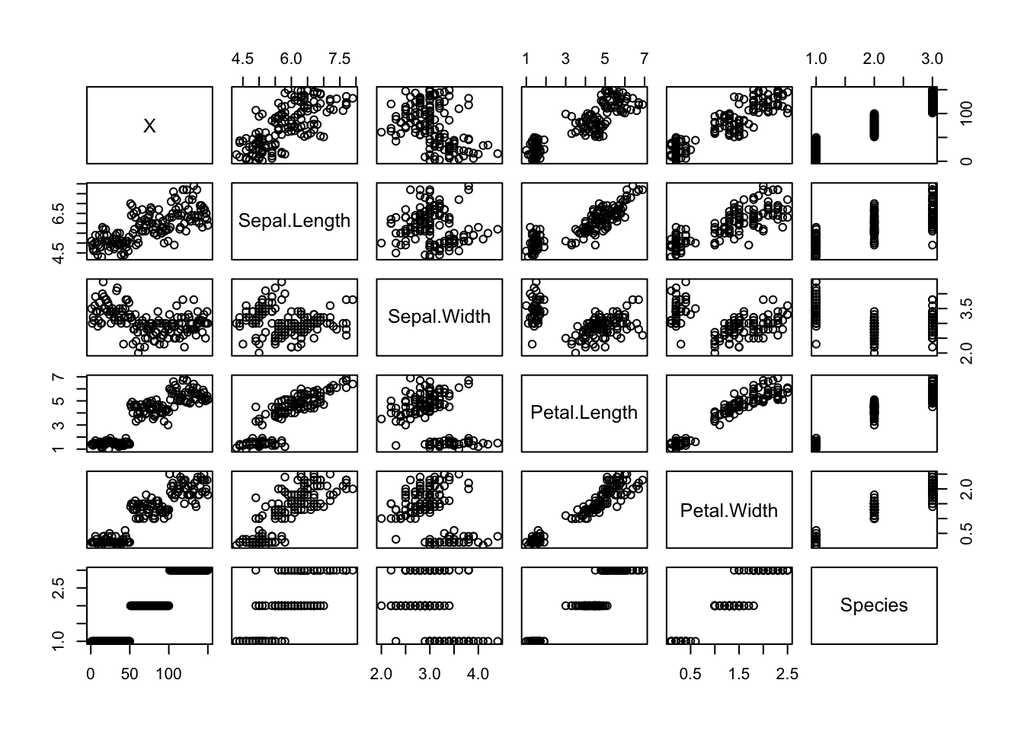

```r
initial.dir <- getwd()
# change to the new Test directory
setwd("~/Desktop/projects/r-starter")

# load the necessary libraries
library(magrittr) #for pipes

# set the output file (it will bypass R and R Studio)
sink("session3.out")
# load the dataset from Test folder
iris <- read.csv("iris.csv")

# Do the analysis
plot(iris)
```

```r
summary(iris)
iris %$% cor(Sepal.Length, Sepal.Width)
# close the output file
sink()

# unload the libraries
detach("package:magrittr")

# change back to the original directory
setwd(initial.dir)
```

## Using forward pipe operator/s in R:

> library(magrittr) required!

```r
library(magrittr)

# Compute the square root of `iris$Sepal.Length` and assign it to the new variable
iris$Sepal.Length.SQRT <- iris$Sepal.Length %>% sqrt()

# Compute the square root of `iris$Sepal.Length` and assign it to the same variable
iris$Sepal.Length %<>% sqrt

# Return `Sepal.Length`
iris$Sepal.Length
```

```
##   [1] 2.258318 2.213594 2.167948 2.144761 2.236068 2.323790 2.144761 2.236068
##   [9] 2.097618 2.213594 2.323790 2.190890 2.190890 2.073644 2.408319 2.387467
##  [17] 2.323790 2.258318 2.387467 2.258318 2.323790 2.258318 2.144761 2.258318
##  [25] 2.190890 2.236068 2.236068 2.280351 2.280351 2.167948 2.190890 2.323790
##  [33] 2.280351 2.345208 2.213594 2.236068 2.345208 2.213594 2.097618 2.258318
##  [41] 2.236068 2.121320 2.097618 2.236068 2.258318 2.190890 2.258318 2.144761
##  [49] 2.302173 2.236068 2.645751 2.529822 2.626785 2.345208 2.549510 2.387467
##  [57] 2.509980 2.213594 2.569047 2.280351 2.236068 2.428992 2.449490 2.469818
##  [65] 2.366432 2.588436 2.366432 2.408319 2.489980 2.366432 2.428992 2.469818
##  [73] 2.509980 2.469818 2.529822 2.569047 2.607681 2.588436 2.449490 2.387467
##  [81] 2.345208 2.345208 2.408319 2.449490 2.323790 2.449490 2.588436 2.509980
##  [89] 2.366432 2.345208 2.345208 2.469818 2.408319 2.236068 2.366432 2.387467
##  [97] 2.387467 2.489980 2.258318 2.387467 2.509980 2.408319 2.664583 2.509980
## [105] 2.549510 2.756810 2.213594 2.701851 2.588436 2.683282 2.549510 2.529822
## [113] 2.607681 2.387467 2.408319 2.529822 2.549510 2.774887 2.774887 2.449490
## [121] 2.626785 2.366432 2.774887 2.509980 2.588436 2.683282 2.489980 2.469818
## [129] 2.529822 2.683282 2.720294 2.810694 2.529822 2.509980 2.469818 2.774887
## [137] 2.509980 2.529822 2.449490 2.626785 2.588436 2.626785 2.408319 2.607681
## [145] 2.588436 2.588436 2.509980 2.549510 2.489980 2.428992
```

## The “tee” pipe operator “%T%”:

> library(magrittr) required!

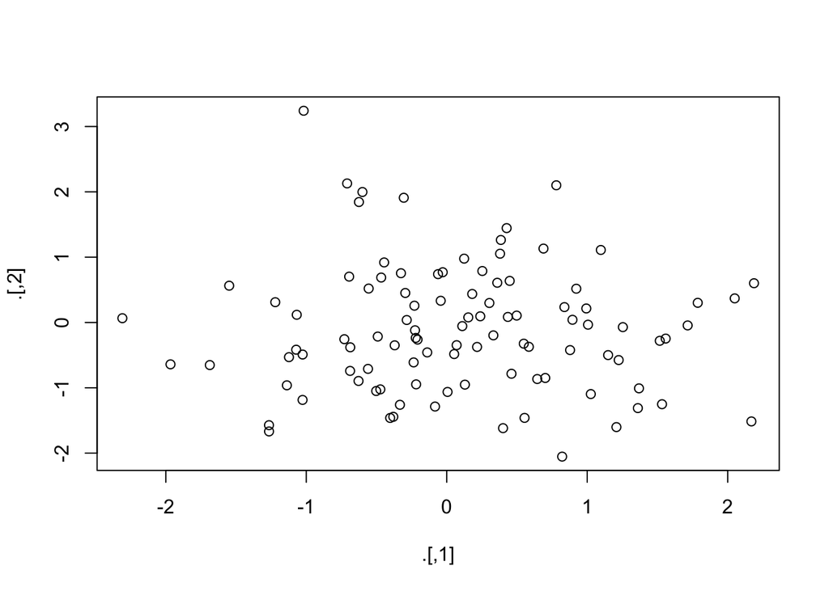

```
## [1]   9.040591 -10.754680
```

```r
set.seed(123)
rnorm(200) %>%
matrix(ncol = 2) %T>%
plot %>%
colSums
```

## The exposing pipe operator “%$%”:

> library(magrittr) required!

```r
iris %>%
subset(Sepal.Length > mean(Sepal.Length)) %$%
cor(Sepal.Length, Sepal.Width)
```

```
## [1] 0.3365679
```

```r
# The %$% operation comes handy for functions where “data” argument is not required/used like built-in “cor” function of R!
cor(iris$Sepal.Length, iris$Sepal.Width)
```

```
## [1] -0.114702
```

## Functions in R: Built-in functions

```r
# round()
round(3.1415)
```

```
## [1] 3
```

```r
round(3.1415, digits = 2)
```

```
## [1] 3.14
```

```r
# factorial()
factorial(3)
```

```
## [1] 6
```

```r
factorial(2*3)
```

```
## [1] 720
```

```r
# mean()
mean(1:6)
```

```
## [1] 3.5
```

```r
mean(c(1:30))
```

```
## [1] 15.5
```

## “Sample” function: Random sampling without or with replacement in R

```r
die <- 1:6
sample(x = die, size = 1)
```

```
## [1] 3
```

```r
sample(x = die, size = 1)
```

```
## [1] 1
```

```r
sample (x = die, size = 1, replace=TRUE)
```

```
## [1] 5
```

```r
sample(x = die, size = 2)
```

```
## [1] 6 1
```

```r
sample(x = die, size = 2)
```

```
## [1] 4 2
```

```r
sample(x = die, size = 2, replace=TRUE)
```

```
## [1] 6 2
```

## “Sample” function to split a datafile into train and test datasets

```r
# Make sure to have “iris.csv” datafile in the working directory and use read.csv to import it in R Studio:
read.csv("iris.csv")
```

```
##       X Sepal.Length Sepal.Width Petal.Length Petal.Width         Species
## 1     1          5.1         3.5          1.4         0.2     Iris-setosa
## 2     2          4.9         3.0          1.4         0.2     Iris-setosa
## 3     3          4.7         3.2          1.3         0.2     Iris-setosa
## 4     4          4.6         3.1          1.5         0.2     Iris-setosa
## 5     5          5.0         3.6          1.4         0.2     Iris-setosa
## 6     6          5.4         3.9          1.7         0.4     Iris-setosa
## 7     7          4.6         3.4          1.4         0.3     Iris-setosa
## 8     8          5.0         3.4          1.5         0.2     Iris-setosa
## 9     9          4.4         2.9          1.4         0.2     Iris-setosa
## 10   10          4.9         3.1          1.5         0.1     Iris-setosa
## 11   11          5.4         3.7          1.5         0.2     Iris-setosa
## 12   12          4.8         3.4          1.6         0.2     Iris-setosa
## 13   13          4.8         3.0          1.4         0.1     Iris-setosa
## 14   14          4.3         3.0          1.1         0.1     Iris-setosa
```

[output cut: 136 more lines]

```r
# We can do the 70:30 random split of iris data frame as follow:
set.seed(123)
tt.sample <- sample(c(TRUE, FALSE), nrow(iris), replace=T, prob=c(0.7,0.3))
train <- iris[tt.sample, ]
test <- iris[!tt.sample, ]
```

## User-defined function in R:

```r
my_function <- function() {}
```

### User-defined function 1: roll()

```r
roll <- function() {
  die <- 1:6
  dice <- sample(die, size = 2, replace = TRUE)
  sum(dice)
}
roll()
```

```
## [1] 9
```

```r
roll()
```

```
## [1] 4
```

```r
roll()
```

```
## [1] 7
```

### User-defined function 2: roll2()

```r
roll2 <- function(dice = 1:6) {
  dice <- sample(dice, size = 2, replace = TRUE)
  sum(dice)
}
roll2()
```

```
## [1] 12
```

```r
roll2()
```

```
## [1] 5
```

```r
roll2()
```

```
## [1] 11
```

### User-defined function 3: roll3(data?)

```r
roll3 <- function(dice) {
  dice <- sample(dice, size = 2, replace = TRUE)
  sum(dice)
}

roll3(1:6)
```

```
## [1] 8
```

```r
roll3(1:12)
```

```
## [1] 16
```

```r
roll3(1:24)
```

```
## [1] 33
```

### More Functions

```r
best_practice <- c("Let", "the", "computer", "do", "the", "work")
print_words <- function(sentence) {
  print(sentence[1])
  print(sentence[2])
  print(sentence[3])
  print(sentence[4])
  print(sentence[5])
  print(sentence[6])
}
print_words(best_practice)
```

```
## [1] "Let"
## [1] "the"
## [1] "computer"
## [1] "do"
## [1] "the"
## [1] "work"
```

```r
print_words(best_practice[-6])
```

```
## [1] "Let"
## [1] "the"
## [1] "computer"
## [1] "do"
## [1] "the"
## [1] NA
```

```r
best_practice[-6]
```

```
## [1] "Let"      "the"      "computer" "do"       "the"
```

## We can use functions with “for” loop in R!

```r
print_words <- function(sentence) {
  for (word in sentence) {
    print(word)
  }
}
print_words(best_practice)
```

```
## [1] "Let"
## [1] "the"
## [1] "computer"
## [1] "do"
## [1] "the"
## [1] "work"
```

```r
print_words(best_practice[-6])
```

```
## [1] "Let"
## [1] "the"
## [1] "computer"
## [1] "do"
## [1] "the"
```

```r
best_practice[-6]
```

```
## [1] "Let"      "the"      "computer" "do"       "the"
```

## Condition: if and else

```r
#Checking values of y with x:
# if (y < 20) {
#   x <- "Too low"
# } else {
#  x <- "Too high"
# }

#Will this work?
check.y <- function(y) {
  if (y < 20) {
    print("Too Low")
  } else {
    print("Two high")
  }
}

check.y(10)
```

```
## [1] "Too Low"
```

```r
check.y(30)
```

```
## [1] "Two high"
```

## Creating binary variables with “ifelse”

```r
y <- 1:40
ifelse(y<20, "Too low", "Too high")
```

```
##  [1] "Too low"  "Too low"  "Too low"  "Too low"  "Too low"  "Too low"
##  [7] "Too low"  "Too low"  "Too low"  "Too low"  "Too low"  "Too low"
## [13] "Too low"  "Too low"  "Too low"  "Too low"  "Too low"  "Too low"
## [19] "Too low"  "Too high" "Too high" "Too high" "Too high" "Too high"
## [25] "Too high" "Too high" "Too high" "Too high" "Too high" "Too high"
## [31] "Too high" "Too high" "Too high" "Too high" "Too high" "Too high"
## [37] "Too high" "Too high" "Too high" "Too high"
```

```r
# It’s a logical as:
ifelse(y<20, TRUE, FALSE)
```

```
##  [1]  TRUE  TRUE  TRUE  TRUE  TRUE  TRUE  TRUE  TRUE  TRUE  TRUE  TRUE  TRUE
## [13]  TRUE  TRUE  TRUE  TRUE  TRUE  TRUE  TRUE FALSE FALSE FALSE FALSE FALSE
## [25] FALSE FALSE FALSE FALSE FALSE FALSE FALSE FALSE FALSE FALSE FALSE FALSE
## [37] FALSE FALSE FALSE FALSE
```

```r
y <- 1:40
ifelse(y<20, 1, 0)
```

```
##  [1] 1 1 1 1 1 1 1 1 1 1 1 1 1 1 1 1 1 1 1 0 0 0 0 0 0 0 0 0 0 0 0 0 0 0 0 0 0 0
## [39] 0 0
```

## Multiple conditions:

```r
if (this) {
# do that
} else if (that) {
# do something else
} else if (that) {
# do something else
} else
# remaining
}
```

```r
check.x <- function(x=1:99){
  if (x<20){
    print("Less than 20")} else{
      if (x<40) {
        print("20-39")
      } else {
        if (x<100) {
          print("41-99")
        }
     }
   }
}
check.x(15)
```

```
## [1] "Less than 20"
```

```r
check.x(30)
```

```
## [1] "20-39"
```

```r
check.x(45)
```

```
## [1] "41-99"
```

## Multiple Conditions: combining “ifelse”

```r
x <- 1:99
x1 <- ifelse(x<20, 1,0) #Binary numbers
x2.1 <- ifelse(x<20, "<20", "20+") #Binary text
# x2.2 # ? For x between 20 and less than 40
# x2.3 # ? For x between 40 and less than 100

x3 <- ifelse(x<20,1,ifelse(x<40,2,3))
x3
```

```
##  [1] 1 1 1 1 1 1 1 1 1 1 1 1 1 1 1 1 1 1 1 2 2 2 2 2 2 2 2 2 2 2 2 2 2 2 2 2 2 2
## [39] 2 3 3 3 3 3 3 3 3 3 3 3 3 3 3 3 3 3 3 3 3 3 3 3 3 3 3 3 3 3 3 3 3 3 3 3 3 3
## [77] 3 3 3 3 3 3 3 3 3 3 3 3 3 3 3 3 3 3 3 3 3 3 3
```

```r
table(x3)
```

```
## x3
##  1  2  3
## 19 20 60
```

```r
#This code shows how Petal. Length categories was created from Petal. Length variable of iris data frame
iris <- within(iris, {
  Petal.cat <- NA
  Petal.cat[Petal.Length <1.6] <- "Small"
  Petal.cat[Petal.Length >=1.6 &
  Petal.Length<5.1] <- "Medium"
  Petal.cat[Petal.Length >=5.1] <- "Large"
})
#The 1.6=Q1 and 5.1=Q3 were obtained from the “summary” of the Petal.Lenght variable i.e. summary(iris$Petal.Length)
iris$Petal.cat
```

```
##   [1] "Small"  "Small"  "Small"  "Small"  "Small"  "Medium" "Small"  "Small"
##   [9] "Small"  "Small"  "Small"  "Medium" "Small"  "Small"  "Small"  "Small"
##  [17] "Small"  "Small"  "Medium" "Small"  "Medium" "Small"  "Small"  "Medium"
##  [25] "Medium" "Medium" "Medium" "Small"  "Small"  "Medium" "Medium" "Small"
##  [33] "Small"  "Small"  "Small"  "Small"  "Small"  "Small"  "Small"  "Small"
##  [41] "Small"  "Small"  "Small"  "Medium" "Medium" "Small"  "Medium" "Small"
##  [49] "Small"  "Small"  "Medium" "Medium" "Medium" "Medium" "Medium" "Medium"
##  [57] "Medium" "Medium" "Medium" "Medium" "Medium" "Medium" "Medium" "Medium"
##  [65] "Medium" "Medium" "Medium" "Medium" "Medium" "Medium" "Medium" "Medium"
##  [73] "Medium" "Medium" "Medium" "Medium" "Medium" "Medium" "Medium" "Medium"
##  [81] "Medium" "Medium" "Medium" "Large"  "Medium" "Medium" "Medium" "Medium"
##  [89] "Medium" "Medium" "Medium" "Medium" "Medium" "Medium" "Medium" "Medium"
##  [97] "Medium" "Medium" "Medium" "Medium" "Large"  "Large"  "Large"  "Large"
## [105] "Large"  "Large"  "Medium" "Large"  "Large"  "Large"  "Large"  "Large"
## [113] "Large"  "Medium" "Large"  "Large"  "Large"  "Large"  "Large"  "Medium"
## [121] "Large"  "Medium" "Large"  "Medium" "Large"  "Large"  "Medium" "Medium"
## [129] "Large"  "Large"  "Large"  "Large"  "Large"  "Large"  "Large"  "Large"
## [137] "Large"  "Large"  "Medium" "Large"  "Large"  "Large"  "Large"  "Large"
## [145] "Large"  "Large"  "Medium" "Large"  "Large"  "Large"
```

```r
table(iris$Petal.cat)
```

```
##
##  Large Medium  Small
##     42     71     37
```

## Multiple Conditions: If, else if, else if, else if

```r
if (temp <= 0) {
"freezing"}
else if (temp <= 10) {
"cold"}
else if (temp <= 20) {
"cool"}
else if (temp <= 30) {
"warm"}
else {
"hot"}
```

```r
temp_description <- function(temp) {
  if (temp <= 0) {
    "freezing"
  } else if (temp <= 10) {
    "cold"
  } else if (temp <= 20) {
    "cool"
  } else if (temp <= 30) {
    "warm"
  } else {
    "hot"
  }
}

# Example usage:
temp_description(0)
```

```
## [1] "freezing"
```

```r
temp_description(10)
```

```
## [1] "cold"
```

```r
temp_description(15)
```

```
## [1] "cool"
```

```r
temp_description(25)
```

```
## [1] "warm"
```

```r
temp_description(35)
```

```
## [1] "hot"
```

## Scraping Covid data from Wikipedia and html parsing

```r
library(rvest)
library(dbplyr)

url <- "https://en.wikipedia.org/wiki/COVID-19_pandemic_in_Nepal#Data"

covid_data <- read_html(url)

table_data <- covid_data %>% html_nodes(".COVID-19_pandemic_data_Nepal_medical_cases table") %>% html_table()

head(table_data)
```

```
## [[1]]
## # A tibble: 496 × 14
##    Date   `Confirmed cases` `Confirmed cases` `Confirmed cases` Recoveries
##    <chr>  <chr>             <chr>             <chr>             <chr>
##  1 Date   Total             New               Active            Total
##  2 23 Jan 1                 +1                1                 0
##  3 24 Jan 1                 0                 1                 0
##  4 25 Jan 1                 0                 1                 0
##  5 26 Jan 1                 0                 1                 0
##  6 27 Jan 1                 0                 1                 0
##  7 28 Jan 1                 0                 1                 0
##  8 29 Jan 1                 0                 0                 1
##  9 30 Jan 1                 0                 0                 1
## 10 31 Jan 1                 0                 0                 1
## # ℹ 486 more rows
## # ℹ 9 more variables: Recoveries <chr>, Deaths <chr>, Deaths <chr>,
## #   `RT-PCR tests` <chr>, `RT-PCR tests` <chr>, TPR <chr>, RR <chr>, CFR <chr>,
## #   Ref. <chr>
```

```r
table_df <- as.data.frame(table_data)
table_df
```

```
##       Date Confirmed.cases Confirmed.cases.1 Confirmed.cases.2 Recoveries
## 1     Date           Total               New            Active      Total
## 2   23 Jan               1                +1                 1          0
## 3   24 Jan               1                 0                 1          0
## 4   25 Jan               1                 0                 1          0
## 5   26 Jan               1                 0                 1          0
## 6   27 Jan               1                 0                 1          0
## 7   28 Jan               1                 0                 1          0
## 8   29 Jan               1                 0                 0          1
## 9   30 Jan               1                 0                 0          1
## 10  31 Jan               1                 0                 0          1
## 11   1 Feb               1                 0                 0          1
## 12   2 Feb               1                 0                 0          1
## 13   3 Feb               1                 0                 0          1
## 14   4 Feb               1                 0                 0          1
```

[output cut: 1476 more lines]

```r
names(table_df)
```

```
##  [1] "Date"              "Confirmed.cases"   "Confirmed.cases.1"
##  [4] "Confirmed.cases.2" "Recoveries"        "Recoveries.1"
##  [7] "Deaths"            "Deaths.1"          "RT.PCR.tests"
## [10] "RT.PCR.tests.1"    "TPR"               "RR"
## [13] "CFR"               "Ref."
```

```r
table_df$Date
```

```
##   [1] "Date"   "23 Jan" "24 Jan" "25 Jan" "26 Jan" "27 Jan" "28 Jan" "29 Jan"
##   [9] "30 Jan" "31 Jan" "1 Feb"  "2 Feb"  "3 Feb"  "4 Feb"  "5 Feb"  "6 Feb"
##  [17] "7 Feb"  "8 Feb"  "9 Feb"  "10 Feb" "11 Feb" "12 Feb" "13 Feb" "14 Feb"
##  [25] "15 Feb" "16 Feb" "17 Feb" "18 Feb" "19 Feb" "20 Feb" "21 Feb" "22 Feb"
##  [33] "23 Feb" "24 Feb" "25 Feb" "26 Feb" "27 Feb" "28 Feb" "29 Feb" "1 Mar"
##  [41] "2 Mar"  "3 Mar"  "4 Mar"  "5 Mar"  "6 Mar"  "7 Mar"  "8 Mar"  "9 Mar"
##  [49] "10 Mar" "11 Mar" "12 Mar" "13 Mar" "14 Mar" "15 Mar" "16 Mar" "17 Mar"
##  [57] "18 Mar" "19 Mar" "20 Mar" "21 Mar" "22 Mar" "23 Mar" "24 Mar" "25 Mar"
##  [65] "26 Mar" "27 Mar" "28 Mar" "29 Mar" "30 Mar" "31 Mar" "1 Apr"  "2 Apr"
##  [73] "3 Apr"  "4 Apr"  "5 Apr"  "6 Apr"  "7 Apr"  "8 Apr"  "9 Apr"  "10 Apr"
##  [81] "11 Apr" "12 Apr" "13 Apr" "14 Apr" "15 Apr" "16 Apr" "17 Apr" "18 Apr"
##  [89] "19 Apr" "20 Apr" "21 Apr" "22 Apr" "23 Apr" "24 Apr" "25 Apr" "26 Apr"
##  [97] "27 Apr" "28 Apr" "29 Apr" "30 Apr" "1 May"  "2 May"  "3 May"  "4 May"
## [105] "5 May"  "6 May"  "7 May"  "8 May"  "9 May"  "10 May" "11 May" "12 May"
## [113] "13 May" "14 May" "15 May" "16 May" "17 May" "18 May" "19 May" "20 May"
```

[output cut: 47 more lines]

```r
head(table_data)
```

```
## [[1]]
## # A tibble: 496 × 14
##    Date   `Confirmed cases` `Confirmed cases` `Confirmed cases` Recoveries
##    <chr>  <chr>             <chr>             <chr>             <chr>
##  1 Date   Total             New               Active            Total
##  2 23 Jan 1                 +1                1                 0
##  3 24 Jan 1                 0                 1                 0
##  4 25 Jan 1                 0                 1                 0
##  5 26 Jan 1                 0                 1                 0
##  6 27 Jan 1                 0                 1                 0
##  7 28 Jan 1                 0                 1                 0
##  8 29 Jan 1                 0                 0                 1
##  9 30 Jan 1                 0                 0                 1
## 10 31 Jan 1                 0                 0                 1
## # ℹ 486 more rows
## # ℹ 9 more variables: Recoveries <chr>, Deaths <chr>, Deaths <chr>,
## #   `RT-PCR tests` <chr>, `RT-PCR tests` <chr>, TPR <chr>, RR <chr>, CFR <chr>,
## #   Ref. <chr>
```

```r
names(table_df)
```

```
##  [1] "Date"              "Confirmed.cases"   "Confirmed.cases.1"
##  [4] "Confirmed.cases.2" "Recoveries"        "Recoveries.1"
##  [7] "Deaths"            "Deaths.1"          "RT.PCR.tests"
## [10] "RT.PCR.tests.1"    "TPR"               "RR"
## [13] "CFR"               "Ref."
```

```r
table.tibble <- tibble::as_tibble(table_df)
```